# Google Data Analytics Capstone | Case Study 2

Alexandra Androutsopoulou

7/11/2021

## How Can a Wellness Technology Company Play It Smart?

[figure not shown]

##### This is my version of the capstone project from the Google Data Analytics Course. It follows the 6 steps of the data analysis process to ensure its completion: Ask, Prepare, Process, Analyze, Share, & Act.

### **STEP 1: ASK**

##### **1.1 BUSINESS TASK**

##### **Analyze FitBit fitness tracker data to gain insights into how customers are using the app, and identify trends and opportunities for Bellabeat’s growth marketing strategy.**

##### **1.2 BUSINESS OBJECTIVES**

###### * What are the trends in smart device usage?

###### * How could these trends apply to Bellabeat customers?

###### * How could these trends help influence Bellabeat marketing strategy?

##### **1.3 KEY STAKEHOLDERS**

###### **Executive team**

###### * Urška Sršen | Bellabeat’s cofounder and Chief Creative Officer

###### * Sando Mur | Mathematician and Bellabeat’s cofounder

###### **Data Science team**

###### * Bellabeat marketing analytics team

##### **1.4 DELIVERABLES**

###### * A clear summary of the business task

###### * A description of all data sources used

###### * Documentation of any cleaning or manipulation of data

###### * A summary of the analysis

###### * Supporting visualizations and key findings

###### * High-level content recommendations based on the analysis

### **STEP 2: PREPARE**

##### **2.1 INFO ON THE DATASET**

###### * 30 eligible Fitbit users consented to the submission of personal tracker data.

###### * Data collected includes physical activity (min), heart rate, sleep monitoring, daily activity and steps.

##### **2.2 LIMITATIONS OF DATASET**

###### * Sample size of 30 FitBit users is not representative of the entire fitness population.

###### * As data is collected in a survey, we are unable to ascertain its integrity or accuracy.

##### **2.3 DOES MY DATA ROCCC?**

###### * Cited — LOW — Unknown, as data collected from third party

###### **Overall, the dataset is considered bad quality data and it is not recommended to produce business recommendations based on this data.**

### **STEP 3: PROCESS**

##### **3.1 TOOLS**

###### I am using **R** for Data Cleaning, Transformation, Analysis and Visualisation.

##### **3.2 SETTING UP MY ENVIRONMENT**

```r
library(tidyverse)
library(lubridate)
```

```r
library(dplyr)
library(ggplot2)
library(readr)
library(here)
library(janitor)
library(skimr)
```

##### **3.3 IMPORTING DATA SET**

#### **I. Daily Activity**

```r
library(readr)
daily_activity <- read_csv("E:/8.Capstone Case Study 2_Bellabeat/Fitabase Data 4.12.16-5.12.16/dailyActivity_merged.csv")
```

#### **II. Daily Calories**

```r
daily_calories <- read_csv("E:/8.Capstone Case Study 2_Bellabeat/Fitabase Data 4.12.16-5.12.16/dailyCalories_merged.csv")
```

#### **III. Daily Intensities**

```r
daily_intensities <- read_csv("E:/8.Capstone Case Study 2_Bellabeat/Fitabase Data 4.12.16-5.12.16/dailyIntensities_merged.csv")
```

#### **IV. Daily Sleep**

```r
daily_sleep <- read_csv("E:/8.Capstone Case Study 2_Bellabeat/Fitabase Data 4.12.16-5.12.16/sleepDay_merged.csv")
```

#### **V. Weight Info**

```r
weight_info <- read_csv("E:/8.Capstone Case Study 2_Bellabeat/Fitabase Data 4.12.16-5.12.16/weightLogInfo_merged.csv")
```

#### **VI.Heartrate Info**

```r
heartrate_info <- read_csv("E:/8.Capstone Case Study 2_Bellabeat/Fitabase Data 4.12.16-5.12.16/heartrate_seconds_merged.csv")
```

##### **3.4 DATA CLEANING**

#### **I. Daily Activity**

```r
head(daily_activity)
```

```
## # A tibble: 6 x 15
##        Id ActivityDate TotalSteps TotalDistance TrackerDistance LoggedActivitie~
##     <dbl> <chr>             <dbl>         <dbl>           <dbl>            <dbl>
## 1  1.50e9 4/12/2016         13162          8.5             8.5                 0
## 2  1.50e9 4/13/2016         10735          6.97            6.97                0
## 3  1.50e9 4/14/2016         10460          6.74            6.74                0
## 4  1.50e9 4/15/2016          9762          6.28            6.28                0
## 5  1.50e9 4/16/2016         12669          8.16            8.16                0
## 6  1.50e9 4/17/2016          9705          6.48            6.48                0
## # ... with 9 more variables: VeryActiveDistance <dbl>,
## #   ModeratelyActiveDistance <dbl>, LightActiveDistance <dbl>,
## #   SedentaryActiveDistance <dbl>, VeryActiveMinutes <dbl>,
## #   FairlyActiveMinutes <dbl>, LightlyActiveMinutes <dbl>,
## #   SedentaryMinutes <dbl>, Calories <dbl>
```

###### **FINDING OUT BASIC INFORMATION ABOUT THE DATA**

###### * **Name of the dataset, Number of rows & columns, Data types**

```r
library (skimr)
skim_without_charts (daily_activity)
```

Data summary

| Name | daily_activity |
| --- | --- |
| Number of rows | 940 |
| Number of columns | 15 |
| _______________________ |  |
| Column type frequency: |  |
| character | 1 |
| numeric | 14 |
| ________________________ |  |
| Group variables | None |

**Variable type: character**

| skim_variable | n_missing | complete_rate | min | max | empty | n_unique | whitespace |
| --- | --- | --- | --- | --- | --- | --- | --- |
| ActivityDate | 0 | 1 | 8 | 9 | 0 | 31 | 0 |

**Variable type: numeric**

| skim_variable | n_missing | complete_rate | mean | sd | p0 | p25 | p50 | p75 | p100 |
| --- | --- | --- | --- | --- | --- | --- | --- | --- | --- |
| Id | 0 | 1 | 4.855407e+09 | 2.424805e+09 | 1503960366 | 2.320127e+09 | 4.445115e+09 | 6.962181e+09 | 8.877689e+09 |
| TotalSteps | 0 | 1 | 7.637910e+03 | 5.087150e+03 | 0 | 3.789750e+03 | 7.405500e+03 | 1.072700e+04 | 3.601900e+04 |
| TotalDistance | 0 | 1 | 5.490000e+00 | 3.920000e+00 | 0 | 2.620000e+00 | 5.240000e+00 | 7.710000e+00 | 2.803000e+01 |
| TrackerDistance | 0 | 1 | 5.480000e+00 | 3.910000e+00 | 0 | 2.620000e+00 | 5.240000e+00 | 7.710000e+00 | 2.803000e+01 |
| LoggedActivitiesDistance | 0 | 1 | 1.100000e-01 | 6.200000e-01 | 0 | 0.000000e+00 | 0.000000e+00 | 0.000000e+00 | 4.940000e+00 |
| VeryActiveDistance | 0 | 1 | 1.500000e+00 | 2.660000e+00 | 0 | 0.000000e+00 | 2.100000e-01 | 2.050000e+00 | 2.192000e+01 |
| ModeratelyActiveDistance | 0 | 1 | 5.700000e-01 | 8.800000e-01 | 0 | 0.000000e+00 | 2.400000e-01 | 8.000000e-01 | 6.480000e+00 |
| LightActiveDistance | 0 | 1 | 3.340000e+00 | 2.040000e+00 | 0 | 1.950000e+00 | 3.360000e+00 | 4.780000e+00 | 1.071000e+01 |
| SedentaryActiveDistance | 0 | 1 | 0.000000e+00 | 1.000000e-02 | 0 | 0.000000e+00 | 0.000000e+00 | 0.000000e+00 | 1.100000e-01 |
| VeryActiveMinutes | 0 | 1 | 2.116000e+01 | 3.284000e+01 | 0 | 0.000000e+00 | 4.000000e+00 | 3.200000e+01 | 2.100000e+02 |
| FairlyActiveMinutes | 0 | 1 | 1.356000e+01 | 1.999000e+01 | 0 | 0.000000e+00 | 6.000000e+00 | 1.900000e+01 | 1.430000e+02 |
| LightlyActiveMinutes | 0 | 1 | 1.928100e+02 | 1.091700e+02 | 0 | 1.270000e+02 | 1.990000e+02 | 2.640000e+02 | 5.180000e+02 |
| SedentaryMinutes | 0 | 1 | 9.912100e+02 | 3.012700e+02 | 0 | 7.297500e+02 | 1.057500e+03 | 1.229500e+03 | 1.440000e+03 |
| Calories | 0 | 1 | 2.303610e+03 | 7.181700e+02 | 0 | 1.828500e+03 | 2.134000e+03 | 2.793250e+03 | 4.900000e+03 |

###### * **Column Names**

```r
colnames(daily_activity)
```

```
##  [1] "Id"                       "ActivityDate"
##  [3] "TotalSteps"               "TotalDistance"
##  [5] "TrackerDistance"          "LoggedActivitiesDistance"
##  [7] "VeryActiveDistance"       "ModeratelyActiveDistance"
##  [9] "LightActiveDistance"      "SedentaryActiveDistance"
## [11] "VeryActiveMinutes"        "FairlyActiveMinutes"
## [13] "LightlyActiveMinutes"     "SedentaryMinutes"
## [15] "Calories"
```

###### **CHECKING FOR NULL/MISSING AND DUBLICATE VALUES IN THE DATA**

```r
sum(is.na(daily_activity))
```

```
## [1] 0
```

```r
sum(duplicated(daily_activity))
```

```
## [1] 0
```

###### **COUNTING UNIQUE IDs TO CONFIRM WHETHER DATA HAS 30 IDs AS CLAIMED BY THE SURVEY**

```r
library(dplyr)
daily_activity %>%
 summarize(unique_Ids = n_distinct(Id))
```

```
## # A tibble: 1 x 1
##   unique_Ids
##        <int>
## 1         33
```

###### **Overall observations**

###### 1. There aren’t Null or missing or duplicate values

###### 2. Data has 15 columns and 940 rows

###### 3. ActivityDate is wrongly classified as character datatype and has to be converted to datetime64 datatype.

###### 4. There are 33 unique IDs, instead of 30 unique IDs as expected.

#### **II. Daily Calories**

```r
head(daily_calories)
```

```
## # A tibble: 6 x 3
##           Id ActivityDay Calories
##        <dbl> <chr>          <dbl>
## 1 1503960366 4/12/2016       1985
## 2 1503960366 4/13/2016       1797
## 3 1503960366 4/14/2016       1776
## 4 1503960366 4/15/2016       1745
## 5 1503960366 4/16/2016       1863
## 6 1503960366 4/17/2016       1728
```

###### **FINDING OUT BASIC INFORMATION ABOUT THE DATA**

###### * **Name of the dataset, Number of rows & columns, Data types**

```r
library (skimr)
skim_without_charts (daily_calories)
```

Data summary

| Name | daily_calories |
| --- | --- |
| Number of rows | 940 |
| Number of columns | 3 |
| _______________________ |  |
| Column type frequency: |  |
| character | 1 |
| numeric | 2 |
| ________________________ |  |
| Group variables | None |

**Variable type: character**

| skim_variable | n_missing | complete_rate | min | max | empty | n_unique | whitespace |
| --- | --- | --- | --- | --- | --- | --- | --- |
| ActivityDay | 0 | 1 | 8 | 9 | 0 | 31 | 0 |

**Variable type: numeric**

| skim_variable | n_missing | complete_rate | mean | sd | p0 | p25 | p50 | p75 | p100 |
| --- | --- | --- | --- | --- | --- | --- | --- | --- | --- |
| Id | 0 | 1 | 4.855407e+09 | 2.424805e+09 | 1503960366 | 2320127002.0 | 4445114986 | 6.962181e+09 | 8877689391 |
| Calories | 0 | 1 | 2.303610e+03 | 7.181700e+02 | 0 | 1828.5 | 2134 | 2.793250e+03 | 4900 |

###### * **Column Names**

```r
colnames(daily_calories)
```

```
## [1] "Id"          "ActivityDay" "Calories"
```

###### **CHECKING FOR NULL/MISSING AND DUBLICATE VALUES IN THE DATA**

```r
sum(is.na(daily_calories))
```

```
## [1] 0
```

```r
sum(duplicated(daily_calories))
```

```
## [1] 0
```

###### **COUNTING UNIQUE IDs**

```r
library(dplyr)
daily_calories %>%
 summarize(unique_Ids = n_distinct(Id))
```

```
## # A tibble: 1 x 1
##   unique_Ids
##        <int>
## 1         33
```

###### **Overall observations**

###### 1. There aren’t Null or missing or duplicate values

###### 2. Data has 3 columns and 940 rows

###### 3. ActivityDay is wrongly classified as character datatype and has to be converted to datetime64 datatype.

###### 4. There are 33 unique IDs, similar number with the daily_activity data frame

#### **III. Daily Intensities**

```r
head(daily_intensities)
```

```
## # A tibble: 6 x 10
##           Id ActivityDay SedentaryMinutes LightlyActiveMinutes FairlyActiveMinu~
##        <dbl> <chr>                  <dbl>                <dbl>             <dbl>
## 1 1503960366 4/12/2016                728                  328                13
## 2 1503960366 4/13/2016                776                  217                19
## 3 1503960366 4/14/2016               1218                  181                11
## 4 1503960366 4/15/2016                726                  209                34
## 5 1503960366 4/16/2016                773                  221                10
## 6 1503960366 4/17/2016                539                  164                20
## # ... with 5 more variables: VeryActiveMinutes <dbl>,
## #   SedentaryActiveDistance <dbl>, LightActiveDistance <dbl>,
## #   ModeratelyActiveDistance <dbl>, VeryActiveDistance <dbl>
```

###### **FINDING OUT BASIC INFORMATION ABOUT THE DATA**

###### * **Name of the dataset, Number of rows & columns, Data types**

```r
library (skimr)
skim_without_charts (daily_intensities)
```

Data summary

| Name | daily_intensities |
| --- | --- |
| Number of rows | 940 |
| Number of columns | 10 |
| _______________________ |  |
| Column type frequency: |  |
| character | 1 |
| numeric | 9 |
| ________________________ |  |
| Group variables | None |

**Variable type: character**

| skim_variable | n_missing | complete_rate | min | max | empty | n_unique | whitespace |
| --- | --- | --- | --- | --- | --- | --- | --- |
| ActivityDay | 0 | 1 | 8 | 9 | 0 | 31 | 0 |

**Variable type: numeric**

| skim_variable | n_missing | complete_rate | mean | sd | p0 | p25 | p50 | p75 | p100 |
| --- | --- | --- | --- | --- | --- | --- | --- | --- | --- |
| Id | 0 | 1 | 4.855407e+09 | 2.424805e+09 | 1503960366 | 2.320127e+09 | 4.445115e+09 | 6.962181e+09 | 8.877689e+09 |
| SedentaryMinutes | 0 | 1 | 9.912100e+02 | 3.012700e+02 | 0 | 7.297500e+02 | 1.057500e+03 | 1.229500e+03 | 1.440000e+03 |
| LightlyActiveMinutes | 0 | 1 | 1.928100e+02 | 1.091700e+02 | 0 | 1.270000e+02 | 1.990000e+02 | 2.640000e+02 | 5.180000e+02 |
| FairlyActiveMinutes | 0 | 1 | 1.356000e+01 | 1.999000e+01 | 0 | 0.000000e+00 | 6.000000e+00 | 1.900000e+01 | 1.430000e+02 |
| VeryActiveMinutes | 0 | 1 | 2.116000e+01 | 3.284000e+01 | 0 | 0.000000e+00 | 4.000000e+00 | 3.200000e+01 | 2.100000e+02 |
| SedentaryActiveDistance | 0 | 1 | 0.000000e+00 | 1.000000e-02 | 0 | 0.000000e+00 | 0.000000e+00 | 0.000000e+00 | 1.100000e-01 |
| LightActiveDistance | 0 | 1 | 3.340000e+00 | 2.040000e+00 | 0 | 1.950000e+00 | 3.360000e+00 | 4.780000e+00 | 1.071000e+01 |
| ModeratelyActiveDistance | 0 | 1 | 5.700000e-01 | 8.800000e-01 | 0 | 0.000000e+00 | 2.400000e-01 | 8.000000e-01 | 6.480000e+00 |
| VeryActiveDistance | 0 | 1 | 1.500000e+00 | 2.660000e+00 | 0 | 0.000000e+00 | 2.100000e-01 | 2.050000e+00 | 2.192000e+01 |

###### * **Column Names**

```r
colnames(daily_intensities)
```

```
##  [1] "Id"                       "ActivityDay"
##  [3] "SedentaryMinutes"         "LightlyActiveMinutes"
##  [5] "FairlyActiveMinutes"      "VeryActiveMinutes"
##  [7] "SedentaryActiveDistance"  "LightActiveDistance"
##  [9] "ModeratelyActiveDistance" "VeryActiveDistance"
```

###### **CHECKING FOR NULL/MISSING AND DUBLICATE VALUES IN THE DATA**

```r
sum(is.na(daily_intensities))
```

```
## [1] 0
```

```r
sum(duplicated(daily_intensities))
```

```
## [1] 0
```

###### **COUNTING UNIQUE IDs**

```r
library(dplyr)
daily_intensities %>%
 summarize(unique_Ids = n_distinct(Id))
```

```
## # A tibble: 1 x 1
##   unique_Ids
##        <int>
## 1         33
```

###### **Overall observations**

###### 1. There aren’t Null or missing or duplicate values

###### 2. Data has 10 columns and 940 rows

###### 3. ActivityDay is wrongly classified as character datatype and has to be converted to datetime64 datatype.

###### 4. There are 33 unique IDs, similar number with the daily_activity and daily_calories data frames

#### **IV. Daily Sleep**

```r
head(daily_sleep)
```

```
## # A tibble: 6 x 5
##           Id SleepDay          TotalSleepRecor~ TotalMinutesAsle~ TotalTimeInBed
##        <dbl> <chr>                        <dbl>             <dbl>          <dbl>
## 1 1503960366 4/12/2016 12:00:~                1               327            346
## 2 1503960366 4/13/2016 12:00:~                2               384            407
## 3 1503960366 4/15/2016 12:00:~                1               412            442
## 4 1503960366 4/16/2016 12:00:~                2               340            367
## 5 1503960366 4/17/2016 12:00:~                1               700            712
## 6 1503960366 4/19/2016 12:00:~                1               304            320
```

###### **FINDING OUT BASIC INFORMATION ABOUT THE DATA**

###### * **Name of the dataset, Number of rows & columns, Data types**

```r
library (skimr)
skim_without_charts (daily_sleep)
```

Data summary

| Name | daily_sleep |
| --- | --- |
| Number of rows | 413 |
| Number of columns | 5 |
| _______________________ |  |
| Column type frequency: |  |
| character | 1 |
| numeric | 4 |
| ________________________ |  |
| Group variables | None |

**Variable type: character**

| skim_variable | n_missing | complete_rate | min | max | empty | n_unique | whitespace |
| --- | --- | --- | --- | --- | --- | --- | --- |
| SleepDay | 0 | 1 | 20 | 21 | 0 | 31 | 0 |

**Variable type: numeric**

| skim_variable | n_missing | complete_rate | mean | sd | p0 | p25 | p50 | p75 | p100 |
| --- | --- | --- | --- | --- | --- | --- | --- | --- | --- |
| Id | 0 | 1 | 5.000979e+09 | 2.06036e+09 | 1503960366 | 3977333714 | 4702921684 | 6962181067 | 8792009665 |
| TotalSleepRecords | 0 | 1 | 1.120000e+00 | 3.50000e-01 | 1 | 1 | 1 | 1 | 3 |
| TotalMinutesAsleep | 0 | 1 | 4.194700e+02 | 1.18340e+02 | 58 | 361 | 433 | 490 | 796 |
| TotalTimeInBed | 0 | 1 | 4.586400e+02 | 1.27100e+02 | 61 | 403 | 463 | 526 | 961 |

###### * **Column Names**

```r
colnames(daily_sleep)
```

```
## [1] "Id"                 "SleepDay"           "TotalSleepRecords"
## [4] "TotalMinutesAsleep" "TotalTimeInBed"
```

###### **CHECKING FOR NULL/MISSING AND DUBLICATE VALUES IN THE DATA**

```r
sum(is.na(daily_sleep))
```

```
## [1] 0
```

```r
sum(duplicated(daily_sleep))
```

```
## [1] 3
```

###### **COUNTING UNIQUE IDs**

```r
library(dplyr)
daily_sleep %>%
 summarize(unique_Ids = n_distinct(Id))
```

```
## # A tibble: 1 x 1
##   unique_Ids
##        <int>
## 1         24
```

###### **Overall observations**

###### 1. There aren’t Null or missing values, but there are 3 dublicate values

###### 2. Data has 5 columns and 413 rows

###### 3. SleepDate is wrongly classified as character datatype and has to be converted to datetime64 datatype.

###### 4. There are 24 unique IDs, less than then 33 of the previous data frames

#### **V. Weight Info**

```r
head(weight_info)
```

```
## # A tibble: 6 x 8
##           Id Date      WeightKg WeightPounds   Fat   BMI IsManualReport    LogId
##        <dbl> <chr>        <dbl>        <dbl> <dbl> <dbl> <lgl>             <dbl>
## 1 1503960366 5/2/2016~     52.6         116.    22  22.6 TRUE            1.46e12
## 2 1503960366 5/3/2016~     52.6         116.    NA  22.6 TRUE            1.46e12
## 3 1927972279 4/13/201~    134.          294.    NA  47.5 FALSE           1.46e12
## 4 2873212765 4/21/201~     56.7         125.    NA  21.5 TRUE            1.46e12
## 5 2873212765 5/12/201~     57.3         126.    NA  21.7 TRUE            1.46e12
## 6 4319703577 4/17/201~     72.4         160.    25  27.5 TRUE            1.46e12
```

###### **FINDING OUT BASIC INFORMATION ABOUT THE DATA**

###### * **Name of the dataset, Number of rows & columns, Data types**

```r
library (skimr)
skim_without_charts (weight_info)
```

Data summary

| Name | weight_info |
| --- | --- |
| Number of rows | 67 |
| Number of columns | 8 |
| _______________________ |  |
| Column type frequency: |  |
| character | 1 |
| logical | 1 |
| numeric | 6 |
| ________________________ |  |
| Group variables | None |

**Variable type: character**

| skim_variable | n_missing | complete_rate | min | max | empty | n_unique | whitespace |
| --- | --- | --- | --- | --- | --- | --- | --- |
| Date | 0 | 1 | 19 | 21 | 0 | 56 | 0 |

**Variable type: logical**

| skim_variable | n_missing | complete_rate | mean | count |
| --- | --- | --- | --- | --- |
| IsManualReport | 0 | 1 | 0.61 | TRU: 41, FAL: 26 |

**Variable type: numeric**

| skim_variable | n_missing | complete_rate | mean | sd | p0 | p25 | p50 | p75 | p100 |
| --- | --- | --- | --- | --- | --- | --- | --- | --- | --- |
| Id | 0 | 1.00 | 7.009282e+09 | 1.950322e+09 | 1.503960e+09 | 6.962181e+09 | 6.962181e+09 | 8.877689e+09 | 8.877689e+09 |
| WeightKg | 0 | 1.00 | 7.204000e+01 | 1.392000e+01 | 5.260000e+01 | 6.140000e+01 | 6.250000e+01 | 8.505000e+01 | 1.335000e+02 |
| WeightPounds | 0 | 1.00 | 1.588100e+02 | 3.070000e+01 | 1.159600e+02 | 1.353600e+02 | 1.377900e+02 | 1.875000e+02 | 2.943200e+02 |
| Fat | 65 | 0.03 | 2.350000e+01 | 2.120000e+00 | 2.200000e+01 | 2.275000e+01 | 2.350000e+01 | 2.425000e+01 | 2.500000e+01 |
| BMI | 0 | 1.00 | 2.519000e+01 | 3.070000e+00 | 2.145000e+01 | 2.396000e+01 | 2.439000e+01 | 2.556000e+01 | 4.754000e+01 |
| LogId | 0 | 1.00 | 1.461772e+12 | 7.829948e+08 | 1.460444e+12 | 1.461079e+12 | 1.461802e+12 | 1.462375e+12 | 1.463098e+12 |

###### * **Column Names**

```r
colnames(weight_info)
```

```
## [1] "Id"             "Date"           "WeightKg"       "WeightPounds"
## [5] "Fat"            "BMI"            "IsManualReport" "LogId"
```

###### **CHECKING FOR NULL/MISSING AND DUBLICATE VALUES IN THE DATA**

```r
sum(is.na(weight_info))
```

```
## [1] 65
```

```r
sum(duplicated(weight_info))
```

```
## [1] 0
```

###### **COUNTING UNIQUE IDs**

```r
library(dplyr)
weight_info %>%
 summarize(unique_Ids = n_distinct(Id))
```

```
## # A tibble: 1 x 1
##   unique_Ids
##        <int>
## 1          8
```

###### 5. There are 8 only unique IDs, less than then 33 of the previous data frames

##### **3.5 DATA MANIPULATION & TRANSFORMATION**

#### **I. Daily Activity**

###### **CONVERTING ‘ActivityDate’ TO DATATIME64 DTYPE**

```r
library(lubridate)
daily_activity$ActivityDate <- mdy(daily_activity$ActivityDate)
head(daily_activity$ActivityDate)
```

```
## [1] "2016-04-12" "2016-04-13" "2016-04-14" "2016-04-15" "2016-04-16"
## [6] "2016-04-17"
```

###### **CREATING NEW COLUMN BY SEPARATING THE ‘ActivityDate’ INTO ‘DayOfTheWeek’ FOR FURTHER ANALYSIS**

```r
library(dplyr)
daily_activity$DayOfTheWeek <- weekdays(daily_activity$ActivityDate)
```

###### **REARRANGING THE COLUMNS**

```r
daily_activity <- daily_activity [, c("Id", "ActivityDate", "DayOfTheWeek", "TotalSteps", "TotalDistance", "TrackerDistance", "LoggedActivitiesDistance", "VeryActiveDistance", "ModeratelyActiveDistance", "LightActiveDistance", "SedentaryActiveDistance", "VeryActiveMinutes", "FairlyActiveMinutes", "LightlyActiveMinutes", "SedentaryMinutes", "Calories")]
head(daily_activity)
```

```
## # A tibble: 6 x 16
##           Id ActivityDate DayOfTheWeek TotalSteps TotalDistance TrackerDistance
##        <dbl> <date>       <chr>             <dbl>         <dbl>           <dbl>
## 1 1503960366 2016-04-12   Τρίτη             13162          8.5             8.5
## 2 1503960366 2016-04-13   Τετάρτη           10735          6.97            6.97
## 3 1503960366 2016-04-14   Πέμπτη            10460          6.74            6.74
## 4 1503960366 2016-04-15   Παρασκευή          9762          6.28            6.28
## 5 1503960366 2016-04-16   Σάββατο           12669          8.16            8.16
## 6 1503960366 2016-04-17   Κυριακή            9705          6.48            6.48
## # ... with 10 more variables: LoggedActivitiesDistance <dbl>,
## #   VeryActiveDistance <dbl>, ModeratelyActiveDistance <dbl>,
## #   LightActiveDistance <dbl>, SedentaryActiveDistance <dbl>,
## #   VeryActiveMinutes <dbl>, FairlyActiveMinutes <dbl>,
## #   LightlyActiveMinutes <dbl>, SedentaryMinutes <dbl>, Calories <dbl>
```

###### **RENAMING ‘ActivityDate’ TO ‘Date’**

```r
daily_activity <- rename(daily_activity, Date=ActivityDate)
```

###### **CREATING NEW COLUMN ‘TotalMinutes’ BEING THE SUM OF TOTAL TIME LOGGED**

```r
daily_activity <- mutate(daily_activity, TotalMinutes = VeryActiveMinutes + FairlyActiveMinutes + LightlyActiveMinutes + SedentaryMinutes)
head(daily_activity$TotalMinutes)
```

```
## [1] 1094 1033 1440  998 1040  761
```

###### **CREATING NEW COLUMN BY CONVERTING ‘TotalMinutes’ TO ‘NumberOfHours’**

```r
daily_activity <- mutate(daily_activity, NumberOfHours = TotalMinutes/60)
head(daily_activity$NumberOfHours)
```

```
## [1] 18.23333 17.21667 24.00000 16.63333 17.33333 12.68333
```

###### **FINALIZING THE COLUMNS’ ORDER**

```r
daily_activity <- daily_activity [, c("Id", "Date", "DayOfTheWeek", "TotalSteps", "TotalDistance", "NumberOfHours", "TrackerDistance", "LoggedActivitiesDistance", "VeryActiveDistance", "ModeratelyActiveDistance", "LightActiveDistance", "SedentaryActiveDistance", "TotalMinutes", "VeryActiveMinutes", "FairlyActiveMinutes", "LightlyActiveMinutes", "SedentaryMinutes", "Calories")]
head(daily_activity)
```

```
## # A tibble: 6 x 18
##           Id Date       DayOfTheWeek TotalSteps TotalDistance NumberOfHours
##        <dbl> <date>     <chr>             <dbl>         <dbl>         <dbl>
## 1 1503960366 2016-04-12 Τρίτη             13162          8.5           18.2
## 2 1503960366 2016-04-13 Τετάρτη           10735          6.97          17.2
## 3 1503960366 2016-04-14 Πέμπτη            10460          6.74          24
## 4 1503960366 2016-04-15 Παρασκευή          9762          6.28          16.6
## 5 1503960366 2016-04-16 Σάββατο           12669          8.16          17.3
## 6 1503960366 2016-04-17 Κυριακή            9705          6.48          12.7
## # ... with 12 more variables: TrackerDistance <dbl>,
## #   LoggedActivitiesDistance <dbl>, VeryActiveDistance <dbl>,
## #   ModeratelyActiveDistance <dbl>, LightActiveDistance <dbl>,
## #   SedentaryActiveDistance <dbl>, TotalMinutes <dbl>, VeryActiveMinutes <dbl>,
## #   FairlyActiveMinutes <dbl>, LightlyActiveMinutes <dbl>,
## #   SedentaryMinutes <dbl>, Calories <dbl>
```

#### **II. Daily Calories**

###### **CONVERTING ‘ActivityDay’ TO DATETIME64 DTYPE**

```r
library(lubridate)
daily_calories$ActivityDay <- mdy(daily_calories$ActivityDay)
head(daily_calories$ActivityDay)
```

```
## [1] "2016-04-12" "2016-04-13" "2016-04-14" "2016-04-15" "2016-04-16"
## [6] "2016-04-17"
```

#### **III. Daily Intensities**

###### **CONVERTING ‘ActivityDay’ TO DATETIME64 DTYPE**

```r
library(lubridate)
daily_intensities$ActivityDay <- mdy(daily_intensities$ActivityDay)
head(daily_intensities$ActivityDay)
```

```
## [1] "2016-04-12" "2016-04-13" "2016-04-14" "2016-04-15" "2016-04-16"
## [6] "2016-04-17"
```

#### **IV. Daily Sleep**

```r
daily_sleep$Sleepday <- as.Date(daily_sleep$SleepDay,"%m/%d/%y")
str(daily_sleep)
```

```
## spec_tbl_df [413 x 6] (S3: spec_tbl_df/tbl_df/tbl/data.frame)
##  $ Id                : num [1:413] 1.5e+09 1.5e+09 1.5e+09 1.5e+09 1.5e+09 ...
##  $ SleepDay          : chr [1:413] "4/12/2016 12:00:00 AM" "4/13/2016 12:00:00 AM" "4/15/2016 12:00:00 AM" "4/16/2016 12:00:00 AM" ...
##  $ TotalSleepRecords : num [1:413] 1 2 1 2 1 1 1 1 1 1 ...
##  $ TotalMinutesAsleep: num [1:413] 327 384 412 340 700 304 360 325 361 430 ...
##  $ TotalTimeInBed    : num [1:413] 346 407 442 367 712 320 377 364 384 449 ...
##  $ Sleepday          : Date[1:413], format: "2020-04-12" "2020-04-13" ...
##  - attr(*, "spec")=
##   .. cols(
##   ..   Id = col_double(),
##   ..   SleepDay = col_character(),
##   ..   TotalSleepRecords = col_double(),
##   ..   TotalMinutesAsleep = col_double(),
##   ..   TotalTimeInBed = col_double()
##   .. )
##  - attr(*, "problems")=<externalptr>
```

###### **REMOVING DUBLICATES**

```r
daily_sleep <- daily_sleep[!duplicated(daily_sleep),]
```

###### **RECHECKING FOR DUBLICATES**

```r
sum(duplicated(daily_sleep))
```

```
## [1] 0
```

#### **V. Weight Info**

###### **CONVERTING ‘Date’ TO DATETIME64 DTYPE**

```r
weight_info$Date <- mdy_hms(weight_info$Date)
```

###### **CONVERTING ‘IsManualReport’ TO LOGICAL DTYPE**

```r
weight_info$IsManualReport <- as.logical(weight_info$IsManualReport)
str(weight_info)
```

```
## spec_tbl_df [67 x 8] (S3: spec_tbl_df/tbl_df/tbl/data.frame)
##  $ Id            : num [1:67] 1.50e+09 1.50e+09 1.93e+09 2.87e+09 2.87e+09 ...
##  $ Date          : POSIXct[1:67], format: "2016-05-02 23:59:59" "2016-05-03 23:59:59" ...
##  $ WeightKg      : num [1:67] 52.6 52.6 133.5 56.7 57.3 ...
##  $ WeightPounds  : num [1:67] 116 116 294 125 126 ...
##  $ Fat           : num [1:67] 22 NA NA NA NA 25 NA NA NA NA ...
##  $ BMI           : num [1:67] 22.6 22.6 47.5 21.5 21.7 ...
##  $ IsManualReport: logi [1:67] TRUE TRUE FALSE TRUE TRUE TRUE ...
##  $ LogId         : num [1:67] 1.46e+12 1.46e+12 1.46e+12 1.46e+12 1.46e+12 ...
##  - attr(*, "spec")=
##   .. cols(
##   ..   Id = col_double(),
##   ..   Date = col_character(),
##   ..   WeightKg = col_double(),
##   ..   WeightPounds = col_double(),
##   ..   Fat = col_double(),
##   ..   BMI = col_double(),
##   ..   IsManualReport = col_logical(),
##   ..   LogId = col_double()
##   .. )
##  - attr(*, "problems")=<externalptr>
```

###### **REMOVING THE ‘Fat’ COLUMN CAUSE 65 OUT OF 67 VALUES ARE MISSING**

```r
weight_info <- select(weight_info, -"Fat")
```

### **STEP 4: ANALYZE**

#### **FOCUSING ON DAILY ACTIVITY & DAILY SLEEP**

##### **Both data frames have the same ‘Id’ field, so they can be merged.**

##### **4.1 UNDERSTANDING SOME SUMMARY STATISTICS**

```r
n_distinct(daily_activity$Id)
```

```
## [1] 33
```

```r
n_distinct(daily_sleep$Id)
```

```
## [1] 24
```

##### **4.2 NUMBER OF OBSERVATIONS IN EACH DATA FRAME**

```r
nrow(daily_activity)
```

```
## [1] 940
```

```r
nrow(daily_sleep)
```

```
## [1] 410
```

###### **4.3 QUICK SUMMARY STATISTICS ABOUT EACH DATA FRAME**

#### **I. Daily Activity**

```r
daily_activity %>%
  select(TotalSteps,
         TotalDistance,
         SedentaryMinutes,
         TotalMinutes,
         Calories) %>%
  summary()
```

```
##    TotalSteps    TotalDistance    SedentaryMinutes  TotalMinutes
##  Min.   :    0   Min.   : 0.000   Min.   :   0.0   Min.   :   2.0
##  1st Qu.: 3790   1st Qu.: 2.620   1st Qu.: 729.8   1st Qu.: 989.8
##  Median : 7406   Median : 5.245   Median :1057.5   Median :1440.0
##  Mean   : 7638   Mean   : 5.490   Mean   : 991.2   Mean   :1218.8
##  3rd Qu.:10727   3rd Qu.: 7.713   3rd Qu.:1229.5   3rd Qu.:1440.0
##  Max.   :36019   Max.   :28.030   Max.   :1440.0   Max.   :1440.0
##     Calories
##  Min.   :   0
##  1st Qu.:1828
##  Median :2134
##  Mean   :2304
##  3rd Qu.:2793
##  Max.   :4900
```

#### **II. Daily Sleep**

```r
daily_sleep %>%
  select(TotalSleepRecords,
  TotalMinutesAsleep,
  TotalTimeInBed) %>%
  summary()
```

```
##  TotalSleepRecords TotalMinutesAsleep TotalTimeInBed
##  Min.   :1.00      Min.   : 58.0      Min.   : 61.0
##  1st Qu.:1.00      1st Qu.:361.0      1st Qu.:403.8
##  Median :1.00      Median :432.5      Median :463.0
##  Mean   :1.12      Mean   :419.2      Mean   :458.5
##  3rd Qu.:1.00      3rd Qu.:490.0      3rd Qu.:526.0
##  Max.   :3.00      Max.   :796.0      Max.   :961.0
```

#### **III. Weight Info**

```r
weight_info %>%
  select(WeightKg,
  BMI) %>%
  summary()
```

```
##     WeightKg           BMI
##  Min.   : 52.60   Min.   :21.45
##  1st Qu.: 61.40   1st Qu.:23.96
##  Median : 62.50   Median :24.39
##  Mean   : 72.04   Mean   :25.19
##  3rd Qu.: 85.05   3rd Qu.:25.56
##  Max.   :133.50   Max.   :47.54
```

#### **4.4 INTERPRETING STATISTICAL FINDINGS**

###### **1. On average, users logged 7,638 steps or 5.5km which is not adequate. As recommended by CDC, an adult female has to aim at least 10,000 steps or 8km per day to benefit from general health, weight loss and fitness improvement. [source: Medical News Today Article](https://www.medicalnewstoday.com/articles/how-many-steps-should-you-take-a-day)**

###### **2. Sedentary users are the majority logging on average 991 minutes or 16.5 hours making up 81% of total average minutes.**

###### **3. Noting that average calories burned is 2,304 calories equivalent to 0.65 pound. Could not interpret into detail as calories burned depend on several factors such as the age, weight, daily tasks, exercise, hormones and daily calorie intake. [source: Health Line Article](https://www.healthline.com/health/fitness-exercise/how-many-calories-do-i-burn-a-day)**

### **STEP 5: SHARE**

#### **DATA VISUALIZATION & FINDINGS**

```r
install.packages("ggplot2")
library("ggplot2")
```

##### **5.1 FREQUENCY OF USAGE ACROSS THE WEEK**

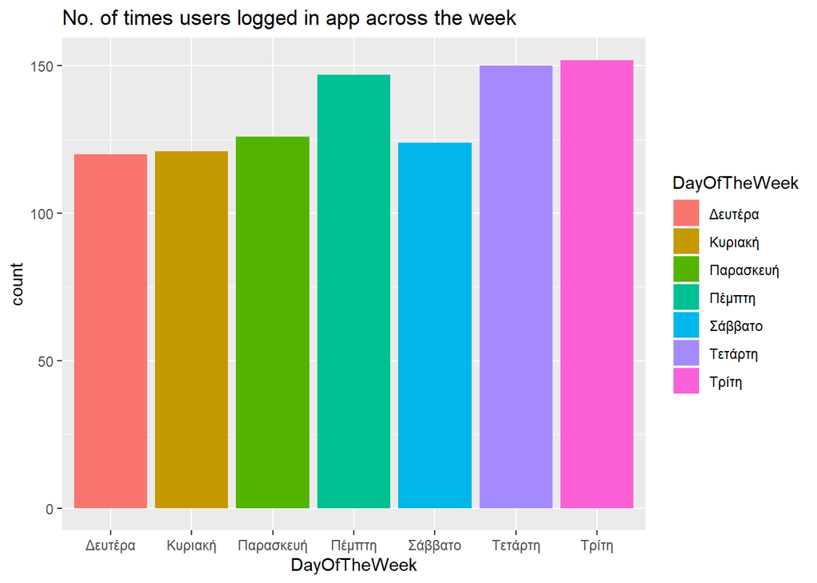

```r
library("ggplot2")
ggplot(data=daily_activity) + geom_bar(mapping=aes(x=DayOfTheWeek,fill=DayOfTheWeek))+
  labs(title="No. of times users logged in app across the week")
```

###### **In this bar chart, we are looking at the frequency of FitBit app usage in terms of days of the week.**

###### **1. We discovered that users prefer to track their activity on the app during midweek from Tuesday to Thursday.**

###### **2. There is a constant drop on frequency from Friday to Monday.**

##### **5.2 CALORIES BURNED FOR EVERY STEP TAKEN**

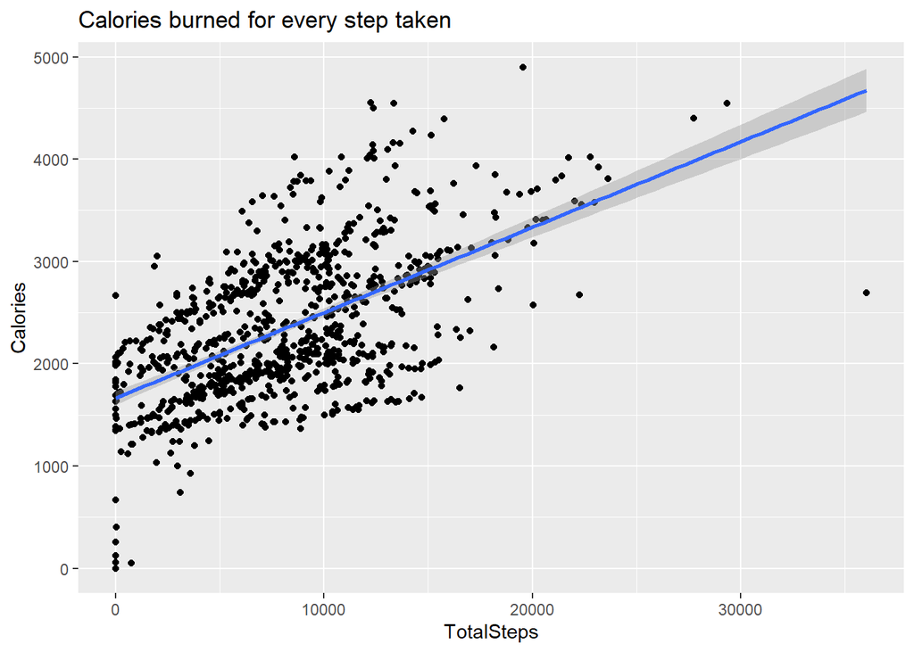

```r
library("ggplot2")
ggplot(data=daily_activity, aes(x=TotalSteps, y = Calories))+ geom_point() + stat_smooth(method=lm)+
   labs(title="Calories burned for every step taken")
```

###### **In the scatter plot above, we can see that:**

###### **1. There is a positive correlation between calories burned and the number of steps.**

###### **2. Intensity of calories burned increases when users are at the range of > 0 to 15,000 steps with calories burn rate cooling down from 15,000 steps onwards.**

###### **Noted a few outliers:**

###### * **1 observation of > 35,000 steps with < 3,000 calories burned.**

###### * **Zero steps with zero to 2,700 calories burned.**

###### **Deduced that outliers could be due to natural variation of data, change in user’s usage or errors in data collection (ie. miscalculations, data contamination or human error).**

##### **5.3 CALORIES BURNED FOR EVERY HOUR LOGGED**

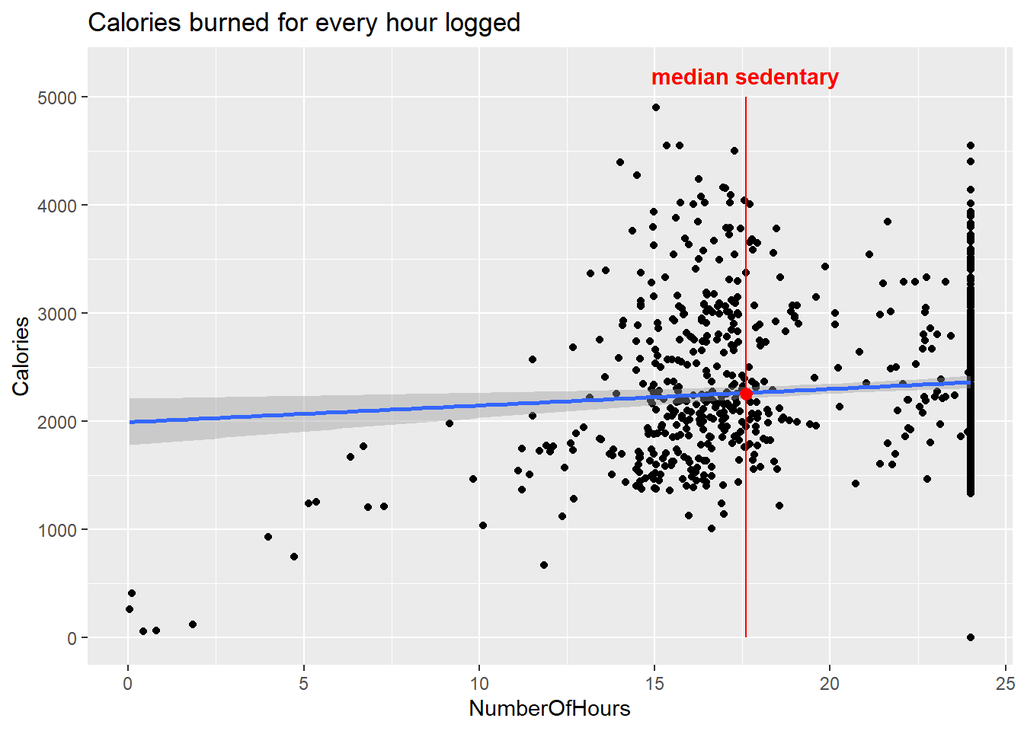

```r
library("ggplot2")
ggplot(data=daily_activity, aes(x=NumberOfHours, y = Calories))+ geom_point() + stat_smooth(method=lm)+
   labs(title="Calories burned for every hour logged")+
  annotate("pointrange", x=17.6, y=2250, ymin=0, ymax=5000, colour="red", size=0.5)+
   annotate("text", x=17.6, y = 5200, label="median sedentary", fontface="bold", color="red")
```

###### **Noted a few outliers:**

###### * **The same zero value outliers**

###### * **An unusual dot at the 24 hours with zero calorie burned which may be due to the same reasons as above.**

##### **5.4 SEDENTARY MINUTES FOR EVERY STEP TAKEN**

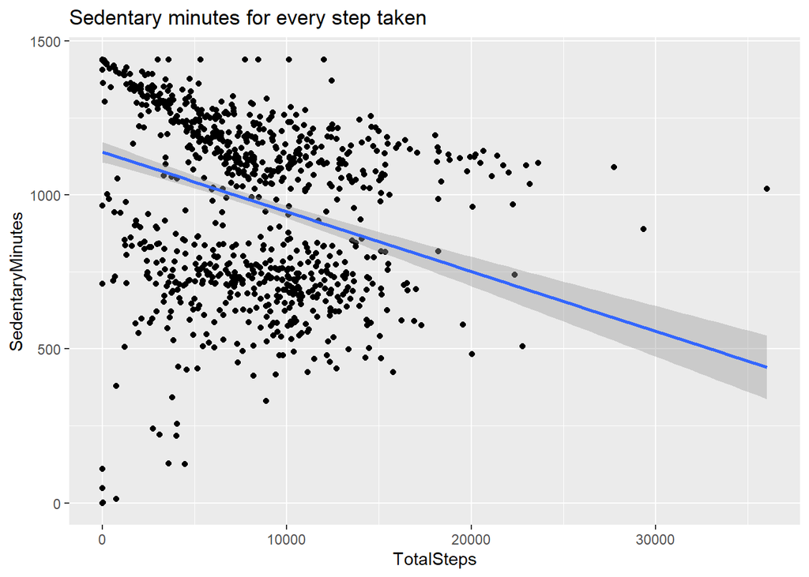

```r
ggplot(data=daily_activity, aes(x=TotalSteps, y = SedentaryMinutes))+ geom_point() + stat_smooth(method=lm)+
  labs(title="Sedentary minutes for every step taken")
```

###### **In the scatter plot above, we can see that:**

###### **1. There is a negative correlation between steps taken in a day and sedentary minutes.**

###### **2. Intensity of sedentary minutes increases when users are at the range of > 5,000 to 15,000 steps with sedentary minutes rate cooling down from 15,000 steps onwards.**

###### **Noted a few outliers:**

###### * **3 observations of > 25,000 steps with > 750 sedentary minutes.**

###### **Deduced that outliers could be due to natural variation of data, change in user’s usage or errors in data collection (ie. miscalculations, data contamination or human error).**

##### **5.5 PERCENTAGE OF ACTIVITY IN MINUTES**

###### * **Summary Data**

```r
active_minutes_summary <- daily_activity %>%
  group_by(Id) %>%
  summarize(avg_very_act_min=mean(VeryActiveMinutes), avg_mod_act_min=mean(FairlyActiveMinutes), avg_light_act_min=mean(LightlyActiveMinutes), avg_sed_min=mean(SedentaryMinutes))
print(active_minutes_summary)
```

```
## # A tibble: 33 x 5
##            Id avg_very_act_min avg_mod_act_min avg_light_act_min avg_sed_min
##         <dbl>            <dbl>           <dbl>             <dbl>       <dbl>
##  1 1503960366          38.7             19.2               220.         848.
##  2 1624580081           8.68             5.81              153.        1258.
##  3 1644430081           9.57            21.4               178.        1162.
##  4 1844505072           0.129            1.29              115.        1207.
##  5 1927972279           1.32             0.774              38.6       1317.
##  6 2022484408          36.3             19.4               257.        1113.
##  7 2026352035           0.0968           0.258             257.         689.
##  8 2320127002           1.35             2.58              198.        1220.
##  9 2347167796          13.5             20.6               252.         687.
## 10 2873212765          14.1              6.13              308         1097.
## # ... with 23 more rows
```

###### * **Total number of activity in minutes**

```r
minutes <- c("ID", "Very Active Minutes", "Fairly Active Minutes", "Lightly Active Minutes", "Sedentary Minutes")
total_min <- colSums(active_minutes_summary)
total_number_per_minutes <- data_frame(minutes, round(total_min, digit=2))
updated_total_number_per_minutes <- slice(total_number_per_minutes, -c(1))
print(total_number_per_minutes)
```

```
## # A tibble: 5 x 2
##   minutes                `round(total_min, digit = 2)`
##   <chr>                                          <dbl>
## 1 ID                                     160287631905
## 2 Very Active Minutes                             670.
## 3 Fairly Active Minutes                           438.
## 4 Lightly Active Minutes                         6320.
## 5 Sedentary Minutes                             32972
```

###### * **Percentage of user activity in minutes**

```r
user_activities_intensity <- slice(updated_total_number_per_minutes, -c(5:8))
pct_total_number_per_minutes <- user_activities_intensity %>%
  mutate(pct = scales::percent((user_activities_intensity$`round(total_min, digit = 2)`)/sum(user_activities_intensity$`round(total_min, digit = 2)`)))
print(pct_total_number_per_minutes)
```

```
## # A tibble: 4 x 3
##   minutes                `round(total_min, digit = 2)` pct
##   <chr>                                          <dbl> <chr>
## 1 Very Active Minutes                             670. 1.66%
## 2 Fairly Active Minutes                           438. 1.08%
## 3 Lightly Active Minutes                         6320. 15.64%
## 4 Sedentary Minutes                             32972  81.61%
```

[figure not shown]

```r
ggplot(pct_total_number_per_minutes, aes(x='', y=pct, fill=minutes))+
  geom_bar(stat = "identity", width=1)+
  coord_polar("y", start=0)+
  theme_void()+
  geom_text(aes(label = pct), color="white",
            position = position_stack(vjust = 0.5))+
  labs(title="Percentage of Activity in Minutes")
```

###### **This indicates that users are using the FitBit app to log daily activities such as daily commute, inactive movements (moving from one spot to another) or running errands.**

###### **App is rarely being used to track fitness (ie. running) as per the minor percentage of fairly active activity (1.08%) and very active activity (1.66%). This is highly discouraging as FitBit app was developed to encourage fitness.**

#### **We could position these findings, as a way to induce the users walking more in terms of exercising, than logging their sedentary daily activities.**

##### **5.6 RELATIONSHIP BETWEEN MINUTES ASLEEP AND TIME IN BED**

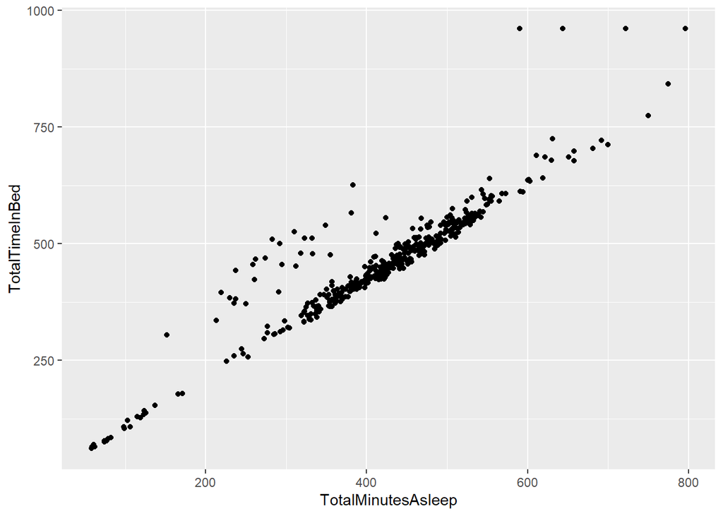

```r
ggplot(data=daily_sleep, aes(x=TotalMinutesAsleep, y=TotalTimeInBed)) + geom_point()
```

###### **As seen from the scatter plot above:**

###### **There is a positive almost completely linear correlation.**

###### **Although, there are some SIGNIFICANT outliers.**

###### * **There are data points that spend a lot of time in bed, but don’t actually sleep, and then a small batch that sleeps and spends time in bed extremely much.**

##### **5.7 MERGING DAILY SLEEP AND DAILY ACTIVITY DATASETS USING OUTER JOIN**

###### **We will use ‘outer_join’ in order to include all the participant Ids from the two datasets.**

```r
combined_data <- merge(x= daily_sleep, y = daily_activity, by="Id",all = TRUE)
head(combined_data)
```

```
##           Id              SleepDay TotalSleepRecords TotalMinutesAsleep
## 1 1503960366 4/12/2016 12:00:00 AM                 1                327
## 2 1503960366 4/12/2016 12:00:00 AM                 1                327
## 3 1503960366 4/12/2016 12:00:00 AM                 1                327
## 4 1503960366 4/12/2016 12:00:00 AM                 1                327
## 5 1503960366 4/12/2016 12:00:00 AM                 1                327
## 6 1503960366 4/12/2016 12:00:00 AM                 1                327
##   TotalTimeInBed   Sleepday       Date DayOfTheWeek TotalSteps TotalDistance
## 1            346 2020-04-12 2016-05-07      Σάββατο      11992          7.71
## 2            346 2020-04-12 2016-05-06    Παρασκευή      12159          8.03
## 3            346 2020-04-12 2016-05-01      Κυριακή      10602          6.81
## 4            346 2020-04-12 2016-04-30      Σάββατο      14673          9.25
## 5            346 2020-04-12 2016-04-12        Τρίτη      13162          8.50
## 6            346 2020-04-12 2016-04-13      Τετάρτη      10735          6.97
##   NumberOfHours TrackerDistance LoggedActivitiesDistance VeryActiveDistance
```

[output cut: 27 more lines]

```r
n_distinct(combined_data$Id)
```

```
## [1] 33
```

##### **5.8 RELATIONSHIP BETWEEN SEDENTARY TIME AND TOTAL TIME IN BED**

```r
sedentary.lm <- lm(SedentaryMinutes ~ TotalTimeInBed, data = combined_data)
print(sedentary.lm)
```

```
##
## Call:
## lm(formula = SedentaryMinutes ~ TotalTimeInBed, data = combined_data)
##
## Coefficients:
##    (Intercept)  TotalTimeInBed
##       922.5632         -0.2688
```

###### **Correlation Coefficient**

```r
cor.test(combined_data$TotalTimeInBed,combined_data$SedentaryMinutes, method = "pearson")
```

```
##
##  Pearson's product-moment correlation
##
## data:  combined_data$TotalTimeInBed and combined_data$SedentaryMinutes
## t = -14.413, df = 12346, p-value < 2.2e-16
## alternative hypothesis: true correlation is not equal to 0
## 95 percent confidence interval:
##  -0.1459457 -0.1112526
## sample estimates:
##        cor
## -0.1286386
```

#### **5.9 RELATIONSHIP BETWEEN TOTAL STEPS AND DAILY SLEEP**

```r
activity.lm <- lm(TotalSteps ~ TotalMinutesAsleep, data = combined_data)
print(activity.lm)
```

```
##
## Call:
## lm(formula = TotalSteps ~ TotalMinutesAsleep, data = combined_data)
##
## Coefficients:
##        (Intercept)  TotalMinutesAsleep
##           9683.122              -3.759
```

###### **Correlation Coefficient**

```r
cor.test(combined_data$TotalMinutesAsleep,combined_data$TotalSteps, method = "pearson")
```

```
##
##  Pearson's product-moment correlation
##
## data:  combined_data$TotalMinutesAsleep and combined_data$TotalSteps
## t = -11.137, df = 12346, p-value < 2.2e-16
## alternative hypothesis: true correlation is not equal to 0
## 95 percent confidence interval:
##  -0.11716060 -0.08223468
## sample estimates:
##         cor
## -0.09972836
```

### **STEP 6: ACT**

#### **DELIVERING INSIGHTS & PROVIDING RECOMMENDATIONS BASED ON ANALYSIS**

##### **REVISITING OUR BUSINESS QUESTIONS AND SHARING OUR BUSINESS RECOMMENDATIONS**

###### * What are the trends in smart device usage?

###### * How could these trends apply to Bellabeat customers?

###### * How could these trends help influence Bellabeat marketing strategy?

###### Both companies develop products focused on providing women with their health, habits and fitness data and encouraging them to understand their current habits and make healthy decisions. These common trends surrounding health and fitness can very well be applied to Bellabeat customers.

##### **TRENDS & RECOMMENDATIONS**

###### Recommendations:

###### * On weekdays, encourage users to share their metrics with friends on social media to drive an increase in user generated content.

###### * On weekends, Bellabeat app can also prompt notification to encourage users to exercise.

###### * Running-routes recommendations, based on user’s personal data (location, workplace/house, gps tracker, most walkable places, etc)

###### **INSIGHT #3:** Although sleep is automatically tracked and logged, a slight drop-off in users is noted and a significant drop off in frequency days logged is observed. Users may have not been wearing the smart device due to discomfort.

###### Recommendation:

###### * Highlight the importance of tracking rest and inform the target market of the product’s features that allow for a comfort feel.

###### **INSIGHT #4:** No data for hydration is present in the Fitbit data set.

###### Recommendation:

###### * Leverage this competitive advantage to differentiate the Bellabeat brand from other smart device companies.

###### * Highlight how the addition of the Spring water bottle completes their product ecosystem and helps users better achieve their health and fitness goals.